# Homework-3

### Challenge 2

```r
library(infer)
library(car)
library(boot)
library(stats)
```

Using bootstrapping, we can also do the same for estimating standard errors and CIs around regression parameters, such as beta coefficients.

Using the “KamilarAndCooperData.csv” dataset, run a linear regression looking at log(MeanGroupSize) in relation to log(Body_mass_female_mean) and report your beta coeffiecients (slope and intercept)

```r
head(d) #recall data
```

```
## # A tibble: 6 x 44
##   Scientific_Name Family Genus Species Brain_Size_Spec… Brain_Size_Fema…
##   <chr>           <chr>  <chr> <chr>              <dbl>            <dbl>
## 1 Allenopithecus… Cerco… Alle… nigrov…             4.06             53.7
## 2 Allocebus_tric… Cerco… Allo… tricho…            NA                NA
## 3 Alouatta_belze… Ateli… Alou… belzeb…             3.97             51.2
## 4 Alouatta_caraya Ateli… Alou… caraya              3.96             47.8
## 5 Alouatta_guari… Ateli… Alou… guariba             3.95             49.1
## 6 Alouatta_palli… Ateli… Alou… pallia…             3.91             48.0
## # … with 38 more variables: Brain_size_Ref <chr>, Body_mass_male_mean <dbl>,
## #   Body_mass_female_mean <dbl>, Mass_Dimorphism <dbl>, Mass_Ref <chr>,
## #   MeanGroupSize <dbl>, AdultMales <dbl>, AdultFemale <dbl>,
## #   AdultSexRatio <dbl>, Social_Organization_Ref <chr>,
## #   InterbirthInterval_d <dbl>, Gestation <dbl>, WeaningAge_d <dbl>,
## #   MaxLongevity_m <dbl>, LitterSz <dbl>, Life_History_Ref <chr>,
## #   GR_MidRangeLat_dd <dbl>, Precip_Mean_mm <dbl>, Temp_Mean_degC <dbl>,
## #   AET_Mean_mm <dbl>, PET_Mean_mm <dbl>, Climate_Ref <chr>,
## #   HomeRange_km2 <dbl>, HomeRangeRef <chr>, DayLength_km <dbl>,
## #   DayLengthRef <chr>, Territoriality <dbl>, Fruit <dbl>, Leaves <chr>,
## #   Fauna <chr>, DietRef1 <chr>, Canine_Dimorphism <dbl>,
## #   Canine_Dimorphism_Ref <chr>, Feed <dbl>, Move <dbl>, Rest <dbl>,
## #   Social <dbl>, Activity_Budget_Ref <chr>
```

```r
lmGroupSize <- lm(log(MeanGroupSize) ~ log(Body_mass_female_mean), data = d)
summary(lmGroupSize)
```

```
##
## Call:
## lm(formula = log(MeanGroupSize) ~ log(Body_mass_female_mean),
##     data = d)
##
## Residuals:
##      Min       1Q   Median       3Q      Max
## -2.85428 -0.66210  0.03604  0.63941  2.51998
##
## Coefficients:
##                            Estimate Std. Error t value Pr(>|t|)
## (Intercept)                -1.77726    0.43752  -4.062 8.06e-05 ***
## log(Body_mass_female_mean)  0.50628    0.05563   9.102 8.08e-16 ***
## ---
## Signif. codes:  0 '***' 0.001 '**' 0.01 '*' 0.05 '.' 0.1 ' ' 1
##
## Residual standard error: 0.9373 on 140 degrees of freedom
##   (71 observations deleted due to missingness)
## Multiple R-squared:  0.3717, Adjusted R-squared:  0.3673
## F-statistic: 82.84 on 1 and 140 DF,  p-value: 8.078e-16
```

```r
#slope coefficient
coef <- lmGroupSize$coefficients
(beta1 <- as.numeric(coef[2]))#slope
```

```
## [1] 0.5062813
```

```r
(beta0 <- as.numeric(coef[1])) #intercept
```

```
## [1] -1.777258
```

Then, use bootstrapping to sample from the dataset 1000 times with replacement, each time fitting the same model and calculating the appropriate coefficients. [The size of each sample should be equivalent to the total number of observations in the dataset.] This generates a bootstrap sampling distribution for each beta coefficient. Plot a histogram of these sampling distributions for beta0 and beta1.

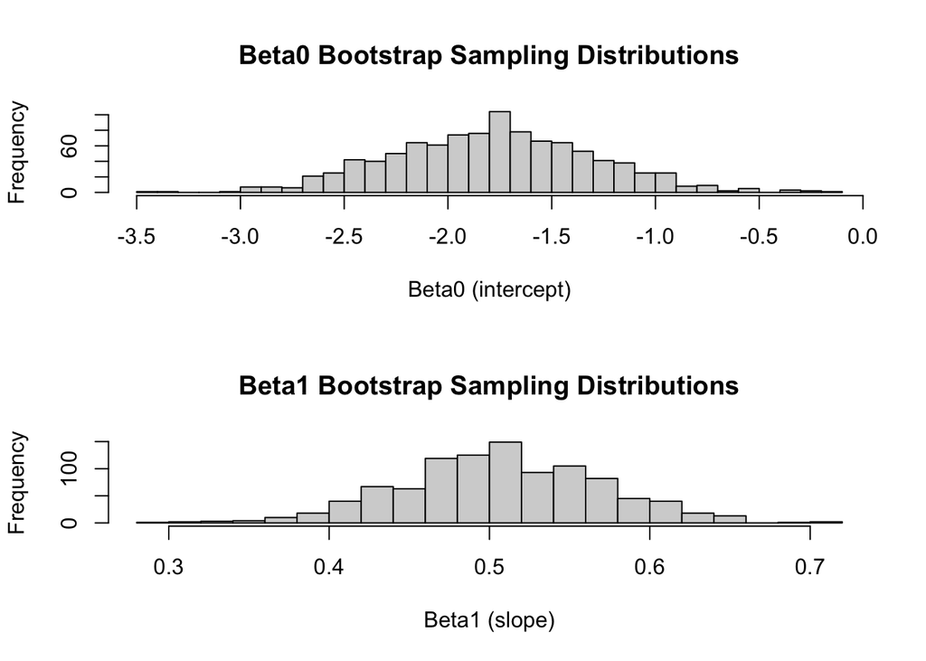

```r
#bootstrap 1000 times
set.seed(5)
bootCoefs <- data.frame(beta0 = 1:1000, beta1 = 1:1000) #store outcome
n <- nrow(d)
for (i in 1:1000) {
  s <- sample_n(d, size = n, replace = T)
  lmboot <- lm(log(MeanGroupSize) ~ log(Body_mass_female_mean), data = s)
  coef <- lmboot$coefficients
  beta0 <- as.numeric(coef[1])
  beta1 <- as.numeric(coef[2])
  bootCoefs$beta0[[i]] <- beta0
  bootCoefs$beta1[[i]] <- beta1
}

#plot a histogram of the sampling distributions for beta 0 and 1
par(mfrow=c(2, 1))
hist(bootCoefs$beta0, breaks = 30, xlab = "Beta0 (intercept)", main = "Beta0 Bootstrap Sampling Distributions")
hist(bootCoefs$beta1, breaks = 30, xlab = "Beta1 (slope)", main = "Beta1 Bootstrap Sampling Distributions")
```

Estimate the standard error for each of your beta coefficients as the standard deviation of the sampling distribution from your bootstrap.

```r
(beta1SE <- sd(bootCoefs$beta1)) #beta1
```

```
## [1] 0.06187259
```

```r
(beta0SE <- sd(bootCoefs$beta0)) #beta0
```

```
## [1] 0.4887741
```

```r
(BootSE <- cbind(beta0SE, beta1SE)) #combine both values
```

```
##        beta0SE    beta1SE
## [1,] 0.4887741 0.06187259
```

Also determine the 95% CI for each of your beta coefficients based on the appropriate quantiles from your sampling distribution.

```r
alpha <- 0.05
beta0lower <- quantile(bootCoefs$beta0, alpha/2)
beta0upper <- quantile(bootCoefs$beta0, 1 - (alpha/2))
beta1lower <- quantile(bootCoefs$beta1, alpha/2)
beta1upper <- quantile(bootCoefs$beta1, 1 - (alpha/2))
(Bootstrapquantiles <- cbind(beta0lower, beta0upper, beta1lower, beta1upper))
```

```
##      beta0lower beta0upper beta1lower beta1upper
## 2.5%  -2.690826 -0.8501434  0.3845505  0.6254107
```

How do the SEs estimated from the bootstrap sampling distribution compare to those estimated mathematically as part of lm() function?

A: They are very similar.

```r
m <- tidy(lmGroupSize)
m$std.error #model
```

```
## [1] 0.43751572 0.05562507
```

```r
b <- BootSE #bootstrap dist.

rbind(b, m$std.error)
```

```
##        beta0SE    beta1SE
## [1,] 0.4887741 0.06187259
## [2,] 0.4375157 0.05562507
```

```r
#bootstrap values are slightly higher than the model values
```

How do your bootstrap CIs compare to those estimated mathematically as part of the lm() function?

A: Also very similar.

```r
CImodel <- confint(lmGroupSize, level = 1 - alpha)
CImodel_lower <- CImodel[, 1]
CImodel_upper <- CImodel[, 2]

(cbind(CImodel_lower, CImodel_upper))
```

```
##                            CImodel_lower CImodel_upper
## (Intercept)                   -2.6422501    -0.9122659
## log(Body_mass_female_mean)     0.3963075     0.6162550
```

```r
Bootstrapquantiles
```

```
##      beta0lower beta0upper beta1lower beta1upper
## 2.5%  -2.690826 -0.8501434  0.3845505  0.6254107
```

### Challenge 3

Write your own function, called boot_lm(), that takes as its arguments a dataframe (d=), a linear model (model=, written as a character string, e.g., “logGS ~ logBM”), a user-defined confidence interval level (conf.level=, with default “0.95”), and a number of bootstrap replicates (reps=, with default “1000”).

```r
#model arguments
boot_lm <- function(d, model, conf.level = 0.95, reps = 1000)  {
  df <- data.frame(Coefficient = c("Beta0", "Beta1"), Coefficientvalue = c(0,0), SE = c(0,0), UpperCI = c(0,0), LowerCI = c(0,0), MeanBetaBoot = c(0,0), SEBoot = c(0,0), UpperCIBoot = c(0,0), LowerCIBoot = c(0,0)) #df to store results of bootstrap
  m <- lm(eval(parse(text = model)), data = d)#linear model using the model and d inputs
  mtidy <- tidy(m)
  df$Coefficientvalue[1] <- as.numeric(mtidy[1,2])
  df$Coefficientvalue[2] <- as.numeric(mtidy[2,2])
  df$SE[1] <- as.numeric(mtidy[1,3])
  df$SE[2] <- as.numeric(mtidy[2,3])
  modelCI <- confint(m, level = conf.level)
  df$UpperCI[1] <- modelCI[1,2]
  df$UpperCI[2] <- modelCI[2,2]
  df$LowerCI[1] <- modelCI[1,1]
  df$LowerCI[1] <- modelCI[2,1]
  set.seed(5) #for bootstrap
  bootstrap <- data.frame(beta0 = 1:reps, beta1 = 1:reps)
  n <- nrow(d)
  for (i in 1:reps){
    s <- sample_n(d, size = n, replace = T)
    mboot <- lm(eval(parse(text = model)), data = s)
    Bootlm <- mboot$coefficients
    beta0 <- as.numeric(Bootlm[1])
    beta1 <- as.numeric(Bootlm[2])
    bootstrap$beta0[[i]] <- beta0
    bootstrap$beta1[[i]] <- beta1
  }
  df$MeanBetaBoot[1] <- mean(bootstrap$beta0)
  df$MeanBetaBoot[2] <- mean(bootstrap$beta1)
  df$SEBoot[1] <- sd(bootstrap$beta0)
  df$SEBoot[2] <- sd(bootstrap$beta1)
  alpha <- 1 - conf.level
  df$UpperCIBoot[1] <- quantile(bootstrap$beta0, 1 - (alpha/2))
  df$UpperCIBoot[2] <- quantile(bootstrap$beta1, 1 - (alpha/2))
  df$LowerCIBoot[1] <- quantile(bootstrap$beta0, alpha/2)
  df$LowerCIBoot[2] <- quantile(bootstrap$beta1, alpha/2)
  df
}

a <- boot_lm(d, "log(MeanGroupSize) ~ log(Body_mass_female_mean)")
a
```

```
##   Coefficient Coefficientvalue         SE    UpperCI   LowerCI MeanBetaBoot
## 1       Beta0       -1.7772580 0.43751572 -0.9122659 0.3963075    -1.785919
## 2       Beta1        0.5062813 0.05562507  0.6162550 0.0000000     0.507383
##       SEBoot UpperCIBoot LowerCIBoot
## 1 0.48877408  -0.8501434  -2.6908259
## 2 0.06187259   0.6254107   0.3845505
```

```r
b <- boot_lm(d, "log(DayLength_km) ~ log(Body_mass_female_mean)")
b
```

```
##   Coefficient Coefficientvalue        SE   UpperCI     LowerCI MeanBetaBoot
## 1       Beta0       -0.1427624 0.4650068 0.7795764 -0.07347022  -0.13683825
## 2       Beta1        0.0389422 0.0566739 0.1513546  0.00000000   0.03791644
##       SEBoot UpperCIBoot LowerCIBoot
## 1 0.48780057   0.7656472 -1.13451781
## 2 0.06153541   0.1608548 -0.07604676
```

```r
c <- boot_lm(d, "log(DayLength_km) ~ log(Body_mass_female_mean) + log(MeanGroupSize)")
c
```

```
##   Coefficient Coefficientvalue         SE    UpperCI    LowerCI MeanBetaBoot
## 1       Beta0      -0.29916271 0.48590764 0.66663134 -0.2157728  -0.26437133
## 2       Beta1      -0.08813683 0.06421586 0.03949915  0.0000000  -0.09409768
##       SEBoot UpperCIBoot LowerCIBoot
## 1 0.46010210  0.62590709  -1.1245216
## 2 0.05800141  0.01554985  -0.2110745
```